# Ejercicios intervalos de confianza y pruebas de hipótesis

Nicolás Molano Gonzalez

January 1, 2015

# Formulas de intervalos de confianza

## Intervalo de confianza para el valor esperado

La formula del intervalo de confianza para el valor esperado tiene la siguiente formula:

$$\Bigg(\bar{X}-t_{n-1,1-\frac{\alpha}{2}}\times\frac{S}{\sqrt{n}},\bar{X}-t_{n-1,\frac{\alpha}{2}}\times\frac{S}{\sqrt{n}}\Bigg)$$

Donde:

- $\bar{X}$ es el promedio calculado con la muestra
- $S$ Es la desviacion estandar calculada con la muestra
- $n$ es el tamaño de la muestra y $\sqrt{n}$ su raiz cuadrada
- $t_{n-1,\frac{\alpha}{2}}$ es el cuantil $\frac{\alpha}{2}$ de la distribucion $T$ con $n-1$ grados de libertad
- $t_{n-1,1-\frac{\alpha}{2}}$ es el cuantil $1-\frac{\alpha}{2}$ de la distribucion $T$ con $n-1$ grados de libertad

Por ejemplo en la figura se muestran los cuantiles $t_{70,0.025}=-1.994$ y $t_{70,0.975}=1.994$ para una distribucion $T$ con $70$ grados de libertad.

[figure not shown]

Desnidad de la distribucion T

Es importante entender que el parametro grados de libertad cambia la forma de la curva, como se puede apreciar en la figura

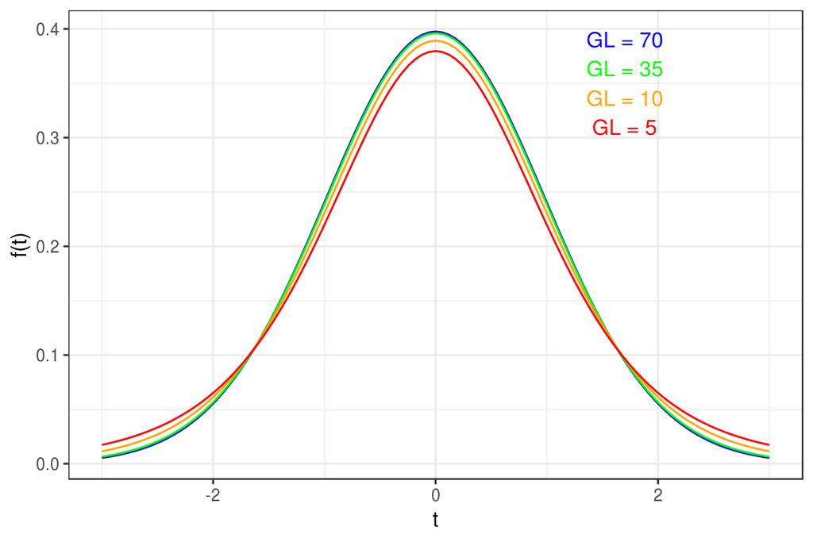

Grados de libertad en la distribucion T

Al cambiar la forma de la curva, el valor de los cuantiles cambia tambien, como se puede apreciar en la siguiente tabla

| GL | t_0.05 |
| --- | --- |
| 70 | -1.666915 |
| 35 | -1.689572 |
| 10 | -1.812461 |
| 5 | -2.015048 |

## Intervalo de confianza para la varianza

La formula del intervalo de confianza para la varianza tiene la siguiente formula:

$$\Bigg( S-t_{n-1,1-\frac{\alpha}{2}}\times\frac{S}{\sqrt{n}},\bar{X}-t_{n-1,\frac{\alpha}{2}}\times\frac{S}{\sqrt{n}}\Bigg)$$

# Ejercicio 1

El peso de 71 gallinas fue medido en kilogramos. Calcule el intervalo de confianza al 95% para el valor esperado de esta muestra en base a la siguiente información:

- $\bar{X}=$ 261.31
- $S=$ 78.074
- $n=$ 71
- $\alpha= 0.05$ ya que la confianza es del 95%

Escoja los cuantiles adecuados para calcular el intervalo de confianza:

| GL | q0.025 | q0.05 | q0.1 | q0.9 | q0.95 | q0.975 |
| --- | --- | --- | --- | --- | --- | --- |
| 5 | -2.570582 | -2.015048 | -1.475884 | 1.475884 | 2.015048 | 2.570582 |
| 10 | -2.228139 | -1.812461 | -1.372184 | 1.372184 | 1.812461 | 2.228139 |
| 35 | -2.030108 | -1.689572 | -1.306212 | 1.306212 | 1.689572 | 2.030108 |
| 70 | -1.994437 | -1.666915 | -1.293763 | 1.293763 | 1.666915 | 1.994437 |
| 100 | -1.983971 | -1.660234 | -1.290075 | 1.290075 | 1.660234 | 1.983971 |

Ahora calcule el intervalo con un nivel de confianza del 90%

# Ejercicio 2